# Results EE-goals Study 1

Markus Steiner

22 Juli 2017

# Getting what you came for: Decisions under uncertainty with a goal.

This study investigated the influence of a minimum aspiration level (goal) in a bandit task on participants’ behavior. The study had a 2 x 3 between subjects design with the following conditions:

- **Goal condition**:
  - No Goal
  - Goal of 100 points
- **Variance condition:**
  - Equal (Equal EVs, different variance)
  - Low (High EV option has low variance)
  - High (High EV option has high variance)

Means and standard deviations of the conditions were the following:

Means and standard deviations of the three environments from the variance condition.

| Condition | 1 | 2 |
| --- | --- | --- |
| Equal: Same EV; Different Variance | mean = 4; sd = 2.5 | mean = 4; sd = 11 |
| Low: Different EV, High Variance = low EV | mean = 4; sd = 2.5 | mean = 2.5; sd = 11 |
| High: Different EV, High Variance = high EV | mean = 2.5; sd = 2.5 | mean = 4; sd =11 |

# Preregistered Hypotheses

This table shows the different hypotheses we preregistered and whether they were supported by our data or not.

[output not shown]

# Preregistered Analyses

## Game Data

Let’s first look at the game data, i.e. the focus is on the behavioral data from the bandit task.

```r
# load study data
df.trial <- readRDS("data/Study1Data/useData/S1_dataTrialLevel.rds")
df.game <- readRDS("data/Study1Data/useData/S1_dataGameLevel.rds")
df.participant <- readRDS("data/Study1Data/useData/S1_dataParticipantLevel.rds")

# load simulation data
df.trial.s <- readRDS("data/SimulationData/useData/S1_dataTrialLevel.rds")
df.game.s <- readRDS("data/SimulationData/useData/S1_dataGameLevel.rds")
df.participant.s <- readRDS("data/SimulationData/useData/S1_dataParticipantLevel.rds")

# check how many participants there were per condition
kable(table(df.participant$goal.condition, df.participant$variance.condition))
```

|  | Equal | High | Low |
| --- | --- | --- | --- |
| Goal | 62 | 61 | 66 |
| NoGoal | 75 | 77 | 69 |

### Proportion of high-variance options chosen given that one is under the goal

First we hypothesized that the probability of selecting the high-variance option given that one is *below* 100 points is *higher* in the goal than in the no goal condition. To test this we ran a logistic mixed effects model with the variance condition and the goal condition as fixed and the game number aswell as participant as random effect.

```r
## Check the probability of selecting high-variance option given that one is BELOW 100 points

m.rug <- lme4::glmer(high.var.chosen ~ variance.condition + goal.condition + (1|game) + (1|id),
               data = subset(df.trial, overGoal == 0 & game > 1), family = binomial)

summary(m.rug)
```

```
## Generalized linear mixed model fit by maximum likelihood (Laplace
##   Approximation) [glmerMod]
##  Family: binomial  ( logit )
## Formula: high.var.chosen ~ variance.condition + goal.condition + (1 |
##     game) + (1 | id)
##    Data: subset(df.trial, overGoal == 0 & game > 1)
##
##      AIC      BIC   logLik deviance df.resid
## 117377.5 117434.2 -58682.8 117365.5    92765
##
## Scaled residuals:
##     Min      1Q  Median      3Q     Max
## -2.6887 -0.7986 -0.5383  1.0473  4.1630
##
## Random effects:
##  Groups Name        Variance Std.Dev.
##  id     (Intercept) 0.391590 0.6258
##  game   (Intercept) 0.008281 0.0910
## Number of obs: 92771, groups:  id, 410; game, 10
##
## Fixed effects:
##                        Estimate Std. Error z value Pr(>|z|)
## (Intercept)            -0.43556    0.07111  -6.125 9.07e-10 ***
## variance.conditionHigh  0.40020    0.07743   5.169 2.36e-07 ***
## variance.conditionLow  -0.23663    0.07792  -3.037  0.00239 **
## goal.conditionNoGoal   -0.12519    0.06371  -1.965  0.04940 *
## ---
## Signif. codes:  0 '***' 0.001 '**' 0.01 '*' 0.05 '.' 0.1 ' ' 1
##
## Correlation of Fixed Effects:
##             (Intr) vrnc.H vrnc.L
## vrnc.cndtnH -0.543
## vrnc.cndtnL -0.558  0.499
## gl.cndtnNGl -0.490 -0.009  0.030
```

```r
confint.merMod(m.rug, method = "Wald", parallel = "multicore")
```

```
##                             2.5 %        97.5 %
## .sig01                         NA            NA
## .sig02                         NA            NA
## (Intercept)            -0.5749425 -0.2961867570
## variance.conditionHigh  0.2484401  0.5519587538
## variance.conditionLow  -0.3893497 -0.0839067974
## goal.conditionNoGoal   -0.2500577 -0.0003301896
```

As predicted, the high variance option is chosen less often (OR = 0.88) than the goal condition ($z = -1.97, p = .049$). Additionally there were effects of the variance condition on the likelyhood of choosing the high variance option ($OR_{High vs Equal}$ = 1.49, $z = 5.17, p < .001$; $OR_{Low vs Equal}$ = 0.79 $, z = -3.04, p = .002$). Figure 1 shows that the pattern found in study 1 is compatible with the pattern found in the simulation, although less extreme.

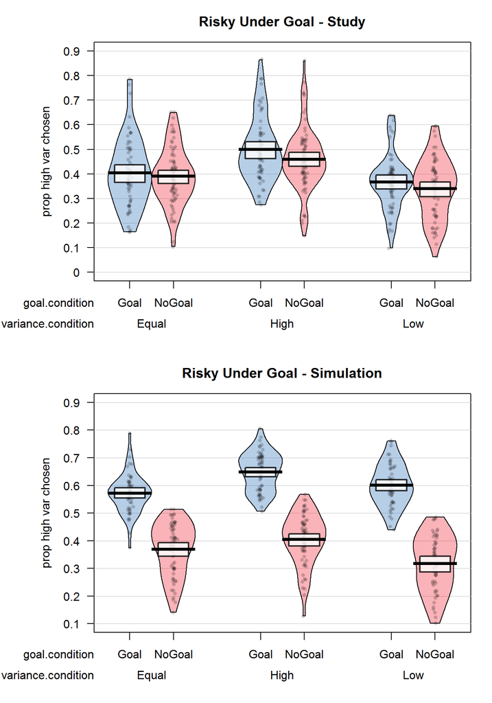

Figure 1: Proportion of high variance chosen under 100 points separated for goal condition and variance condition. Top: Study data. Bottom: Simulation Data.

```r
par(mfrow = c(2,1), mar=c(5,6.7,3,1.5))
yarrr::pirateplot(risky.ug ~ goal.condition + variance.condition, data = df.participant,
           ylab = "prop high var chosen", xlab = "Conditions", main = "Risky Under Goal - Study")

yarrr::pirateplot(risky.ug ~ goal.condition + variance.condition, data = df.participant.s,
           ylab = "prop high var chosen", xlab = "Conditions", main = "Risky Under Goal - Simulation")
```

### Proportion of high-variance options chosen given that one is above the goal

Next we test the hypothesis that the probability of selecting the high-variance option given that one is *above* 100 points is *lower* in the goal than in the no goal condition. I.e, we expect a switch in the pattern of the probability of selecting the high-variance option given that one is *under* the goal. To test this we again ran a logistic mixed effects model with the variance condition and the goal condition as fixed and the game number aswell as participant as random effect.

```r
## Check the probability of selecting high-variance option given that one is ABOVE 100 points

m.rag <- lme4::glmer(high.var.chosen ~ variance.condition + goal.condition + (1|game) + (1|id),
               data = subset(df.trial, overGoal == 1 & game > 1), family = binomial)
summary(m.rag)
```

```
## Generalized linear mixed model fit by maximum likelihood (Laplace
##   Approximation) [glmerMod]
##  Family: binomial  ( logit )
## Formula: high.var.chosen ~ variance.condition + goal.condition + (1 |
##     game) + (1 | id)
##    Data: subset(df.trial, overGoal == 1 & game > 1)
##
##      AIC      BIC   logLik deviance df.resid
##  10565.2  10608.3  -5276.6  10553.2     9723
##
## Scaled residuals:
##     Min      1Q  Median      3Q     Max
## -3.4888 -0.6475 -0.2509  0.7439  4.5278
##
## Random effects:
##  Groups Name        Variance Std.Dev.
##  id     (Intercept) 2.32417  1.5245
##  game   (Intercept) 0.02628  0.1621
## Number of obs: 9729, groups:  id, 400; game, 10
##
## Fixed effects:
##                        Estimate Std. Error z value Pr(>|z|)
## (Intercept)             -1.4247     0.1769  -8.052 8.14e-16 ***
## variance.conditionHigh   1.3097     0.2046   6.400 1.55e-10 ***
## variance.conditionLow   -0.3091     0.2029  -1.523    0.128
## goal.conditionNoGoal     0.9841     0.1678   5.863 4.54e-09 ***
## ---
## Signif. codes:  0 '***' 0.001 '**' 0.01 '*' 0.05 '.' 0.1 ' ' 1
##
## Correlation of Fixed Effects:
##             (Intr) vrnc.H vrnc.L
## vrnc.cndtnH -0.558
## vrnc.cndtnL -0.568  0.473
## gl.cndtnNGl -0.533  0.016  0.042
```

```r
confint.merMod(m.rag, method = "Wald", parallel = "multicore")
```

```
##                             2.5 %      97.5 %
## .sig01                         NA          NA
## .sig02                         NA          NA
## (Intercept)            -1.7714879 -1.07791189
## variance.conditionHigh  0.9085824  1.71072993
## variance.conditionLow  -0.7067723  0.08859429
## goal.conditionNoGoal    0.6550919  1.31301152
```

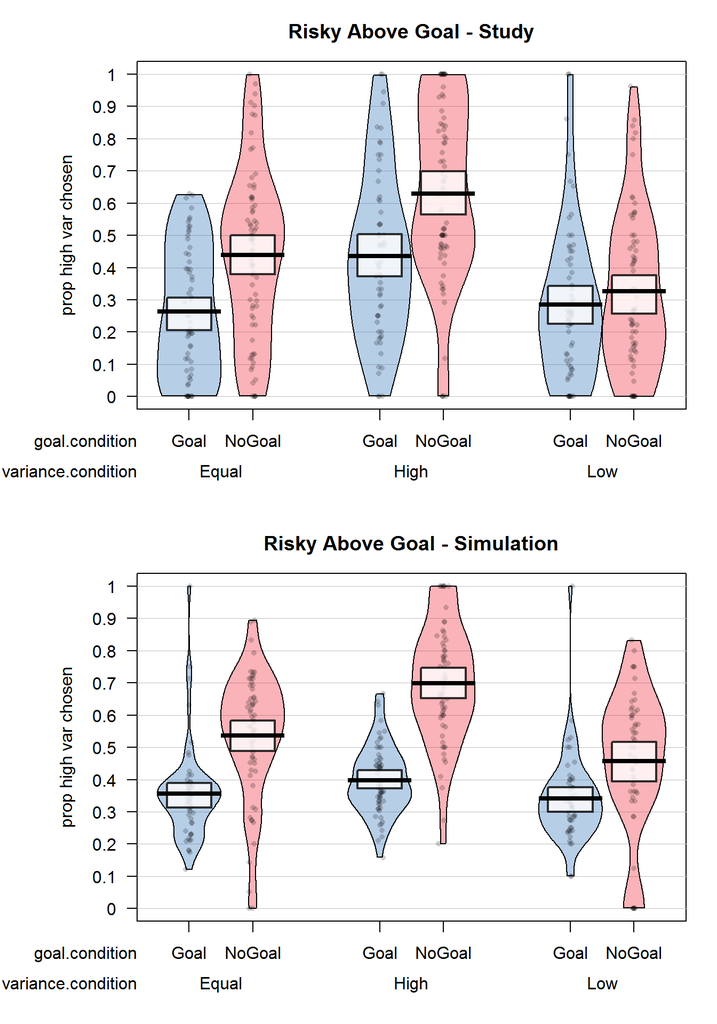

Figure 2: Proportion of high variance chosen over 100 points separated for goal condition and variance condition. Top: Study data. Bottom: Simulation Data.

```r
par(mfrow = c(2,1), mar=c(5,6.7,3,1.5))
yarrr::pirateplot(risky.ag ~ goal.condition + variance.condition, data = df.participant,
           ylab = "prop high var chosen", xlab = "Conditions", main = "Risky Above Goal - Study")
yarrr::pirateplot(risky.ag ~ goal.condition + variance.condition, data = df.participant.s,
           ylab = "prop high var chosen", xlab = "Conditions", main = "Risky Above Goal - Simulation")
```

### Proportion of high variance chosen given that it is rational to do so according to RSF

Risk Sensitive Foraging Theory (RSF), makes predictions about which one of possible options should be chosen, given ones relative state to a goal. From this theory we developed a simple model to estimate - given ones current experience - which of the two possible option has the higher likelyhood to reach the goal if one was to pick it for the rest of the game. Let’s call choosing this option a rational decision.

Our hypothesis was that in the goal condition the high variance option is chosen more often if, according to our RSF model, it was rational to do so. To test this we again used a logistic mixed effects model, with the RSF model prediction as fixed effect and the game number and participant as random effects.

```r
## With a logistic mixed effects model, check whether, in the goal condition,
#  the high variance option is chosen more often when it is rational to do
#  so according to RSF.

m.chv <- lme4::glmer(high.var.chosen ~ choose.highvar.subj + (1|game) + (1|id),
               data = subset(df.trial, goal.condition == "Goal" & game > 1), family = binomial)
summary(m.chv)
```

```
## Generalized linear mixed model fit by maximum likelihood (Laplace
##   Approximation) [glmerMod]
##  Family: binomial  ( logit )
## Formula: high.var.chosen ~ choose.highvar.subj + (1 | game) + (1 | id)
##    Data: subset(df.trial, goal.condition == "Goal" & game > 1)
##
##      AIC      BIC   logLik deviance df.resid
##  58450.8  58485.9 -29221.4  58442.8    47246
##
## Scaled residuals:
##     Min      1Q  Median      3Q     Max
## -2.1716 -0.7703 -0.5118  0.9512  3.3973
##
## Random effects:
##  Groups Name        Variance Std.Dev.
##  id     (Intercept) 0.348463 0.59031
##  game   (Intercept) 0.004977 0.07055
## Number of obs: 47250, groups:  id, 189; game, 10
##
## Fixed effects:
##                     Estimate Std. Error z value Pr(>|z|)
## (Intercept)         -0.88170    0.05059  -17.43   <2e-16 ***
## choose.highvar.subj  0.87753    0.02066   42.48   <2e-16 ***
## ---
## Signif. codes:  0 '***' 0.001 '**' 0.01 '*' 0.05 '.' 0.1 ' ' 1
##
## Correlation of Fixed Effects:
##             (Intr)
## chs.hghvr.s -0.211
```

```r
confint.merMod(m.chv, method = "Wald", parallel = "multicore")
```

```
##                          2.5 %     97.5 %
## .sig01                      NA         NA
## .sig02                      NA         NA
## (Intercept)         -0.9808541 -0.7825458
## choose.highvar.subj  0.8370480  0.9180195
```

In the goal condition, choosing the high variance option was more likely when it was rational to do so according to our RSF model ($OR$ = 2.4, $z = 42.48$, $p < .001$). Since our simulations showed that there was also a (much smaller) effect in the no goal condition - given that one assumes a hypothetical goal of 100 - we also calculated the same mixed effects model for the no goal condition, with the hypothesis of a much smaller effect.

```r
m.chv.ng <- lme4::glmer(high.var.chosen ~ choose.highvar.subj + (1|game) + (1|id),
                  data = subset(df.trial, goal.condition == "NoGoal" & game > 1), family = binomial)

summary(m.chv.ng)
```

```
## Generalized linear mixed model fit by maximum likelihood (Laplace
##   Approximation) [glmerMod]
##  Family: binomial  ( logit )
## Formula: high.var.chosen ~ choose.highvar.subj + (1 | game) + (1 | id)
##    Data: subset(df.trial, goal.condition == "NoGoal" & game > 1)
##
##      AIC      BIC   logLik deviance df.resid
##  68489.4  68525.1 -34240.7  68481.4    55246
##
## Scaled residuals:
##     Min      1Q  Median      3Q     Max
## -3.6876 -0.7933 -0.4956  0.9847  4.3017
##
## Random effects:
##  Groups Name        Variance Std.Dev.
##  id     (Intercept) 0.49871  0.70620
##  game   (Intercept) 0.00533  0.07301
## Number of obs: 55250, groups:  id, 221; game, 10
##
## Fixed effects:
##                     Estimate Std. Error z value Pr(>|z|)
## (Intercept)         -0.75558    0.05456  -13.85   <2e-16 ***
## choose.highvar.subj  0.59686    0.01916   31.16   <2e-16 ***
## ---
## Signif. codes:  0 '***' 0.001 '**' 0.01 '*' 0.05 '.' 0.1 ' ' 1
##
## Correlation of Fixed Effects:
##             (Intr)
## chs.hghvr.s -0.180
```

```r
confint.merMod(m.chv.ng, method = "Wald", parallel = "multicore")
```

```
##                          2.5 %     97.5 %
## .sig01                      NA         NA
## .sig02                      NA         NA
## (Intercept)         -0.8625272 -0.6486388
## choose.highvar.subj  0.5593210  0.6344084
```

As predicted the mixed effects model for the no goal condition also showed a positive, but smaller effect of the prediction of our RSF model on whether the high variance option was chosen (OR = 1.82, $z = 31.16$, $p < .001$). Figure 3 shows the effects compared to the simulations. It can be seen that the effect is larger for the goal than the no goal condition in the actual data aswell as the simulation. However the difference between goal and no goal is larger in the simulation.

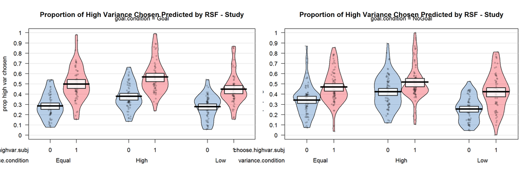

Figure 3: Proportion of high variance chosen separated for conditions and whether it was rational to do so according to our RSF model. Top: Study data. Bottom: Simulation Data.

```r
# plot this result on participant level

# first aggregate to participant level with choose.highvar as dichotomous variable
df.n <- aggregate(high.var.chosen ~ choose.highvar.subj + id + goal.condition + variance.condition,
                  FUN = mean, data = subset(df.trial, game > 1))
df.n.s <- aggregate(high.var.chosen ~ choose.highvar.subj + id + goal.condition + variance.condition,
                  FUN = mean, data = subset(df.trial.s, game > 1))

# plot the proportion of high variance chosen separated for the variance, the goal conditions
# and for whether it was, according to rsf, rational to choose the high variance option

par(mfrow = c(1,1), mar=c(5,7,3,3))
yarrr::pirateplot(high.var.chosen ~ choose.highvar.subj + variance.condition + goal.condition,
                  data = df.n, ylab = "prop high var chosen", xlab = "choose high var subj (rsf)",
                  main = "Proportion of High Variance Chosen Predicted by RSF - Study")
```

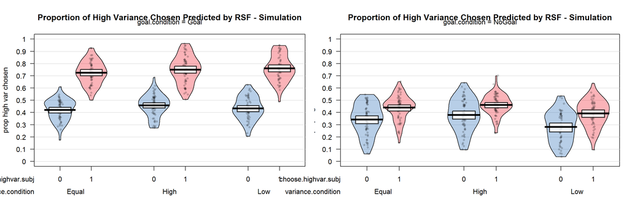

Figure 3: Proportion of high variance chosen separated for conditions and whether it was rational to do so according to our RSF model. Top: Study data. Bottom: Simulation Data.

```r
yarrr::pirateplot(high.var.chosen ~ choose.highvar.subj + variance.condition + goal.condition,
                  data = df.n.s, ylab = "prop high var chosen", xlab = "choose high var subj (rsf)",
                  main = "Proportion of High Variance Chosen Predicted by RSF - Simulation")
```

### Prediction accuracy of RSF and EV model when predictions are differing

Our model to predict behavior in the no goal condition was a form of *expected value* (EV) maximization. The options EVs were computed based on the information participants had sampled before.

To test whether the RSF model did a better job in predicting participants behavior in the goal condition vs. the no goal condition, we looked at the RSF model’s prediction accuracy in the cases in which the two models made opposing predicitons. We expected that in the goal condition, the RSF model would be more accurate in predicting participants choices, than in the no goal condition.

The two models’ predictions differed in, on average, $\Delta_{overall} = 38.7\%$ of the trials (separated per variance condition: $\Delta_{Equal} = 40.7\%$, $\Delta_{Low} = 38.6\%$, $\Delta_{High} = 36.9\%$).

```r
m.pa <- lme4::glmer(pred.RSF.acc ~ goal.condition + (1|game) + (1|id),
              data = subset(df.trial, game > 1 & pred.EV != pred.RSF), family = binomial)

summary(m.pa)
```

```
## Generalized linear mixed model fit by maximum likelihood (Laplace
##   Approximation) [glmerMod]
##  Family: binomial  ( logit )
## Formula: pred.RSF.acc ~ goal.condition + (1 | game) + (1 | id)
##    Data: subset(df.trial, game > 1 & pred.EV != pred.RSF)
##
##      AIC      BIC   logLik deviance df.resid
##  52087.4  52121.7 -26039.7  52079.4    39648
##
## Scaled residuals:
##     Min      1Q  Median      3Q     Max
## -2.5706 -0.8642 -0.5601  0.9829  2.8714
##
## Random effects:
##  Groups Name        Variance Std.Dev.
##  id     (Intercept) 0.37343  0.6111
##  game   (Intercept) 0.02846  0.1687
## Number of obs: 39652, groups:  id, 410; game, 10
##
## Fixed effects:
##                      Estimate Std. Error z value Pr(>|z|)
## (Intercept)           0.03046    0.07125   0.428    0.669
## goal.conditionNoGoal -0.38519    0.06441  -5.980 2.23e-09 ***
## ---
## Signif. codes:  0 '***' 0.001 '**' 0.01 '*' 0.05 '.' 0.1 ' ' 1
##
## Correlation of Fixed Effects:
##             (Intr)
## gl.cndtnNGl -0.487
```

```r
confint.merMod(m.pa, method = "Wald", parallel = "multicore")
```

```
##                           2.5 %     97.5 %
## .sig01                       NA         NA
## .sig02                       NA         NA
## (Intercept)          -0.1091821  0.1701015
## goal.conditionNoGoal -0.5114302 -0.2589410
```

When the RSF and the EV model make differing predictions, the RSF model is less likely to make the accurate prediction in the no goal compared to the goal condition ($OR = $ 0.68, $z = -5.98$, $p < .001$). In the no goal condition, when the models made differing predictions, RSF was correct in 42.23% of the cases, in the goal condition in 51.16% of the cases. Figure 4 shows this pattern, separated also for the variance condition. It can be seen, that the patterns in the simulation and the study data are the same, although more extreme in the simulation data.

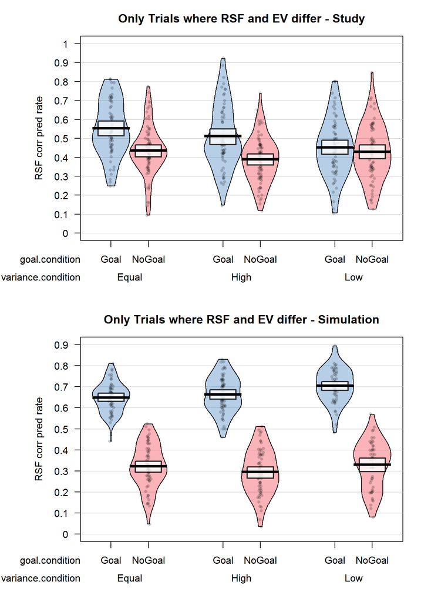

Figure 4: RSF prediction accuracy rates, separated for goal and variance conditions. Top: Study data. Bottom: Simulation Data.

```r
# aggregate using the dplyr package
df.p <- df.trial %>%
  filter(game > 1 & pred.EV != pred.RSF) %>%
  group_by(id, variance.condition, goal.condition) %>%
  summarise(
    pred.EV.acc.rate = mean(pred.EV.acc, na.rm = TRUE),
    pred.RSF.acc.rate = mean(pred.RSF.acc, na.rm = TRUE)
  )

# aggregate using the dplyr package
df.p.s <- df.trial.s %>%
  filter(game > 1 & pred.EV != pred.RSF) %>%
  group_by(id, variance.condition, goal.condition) %>%
  summarise(
    pred.EV.acc.rate = mean(pred.EV.acc, na.rm = TRUE),
    pred.RSF.acc.rate = mean(pred.RSF.acc, na.rm = TRUE)
  )

par(mfrow = c(2,1), mar=c(5,6.7,3,1.5))
yarrr::pirateplot(pred.RSF.acc.rate ~ goal.condition + variance.condition, data = df.p,
           ylab = "RSF corr pred rate", xlab = "Condition", main = "Only Trials where RSF and EV differ - Study")
yarrr::pirateplot(pred.RSF.acc.rate ~ goal.condition + variance.condition, data = df.p.s,
           ylab = "RSF corr pred rate", xlab = "Condition", main = "Only Trials where RSF and EV differ - Simulation")
```

### Proportion of high variance chosen goal vs. no goal

```r
w.hvo <- coin::wilcox_test(high.var.chosen.rate ~ as.factor(goal.condition),
                           data = df.participant)
w.hvo
```

```
##
##  Asymptotic Wilcoxon-Mann-Whitney Test
##
## data:  high.var.chosen.rate by
##   as.factor(goal.condition) (Goal, NoGoal)
## Z = -0.23453, p-value = 0.8146
## alternative hypothesis: true mu is not equal to 0
```

```r
# effect size r
eff.r.hvo <- as.numeric(w.hvo@statistic@teststatistic / sqrt(nrow(df.participant)))
eff.r.hvo
```

```
## [1] -0.0115828
```

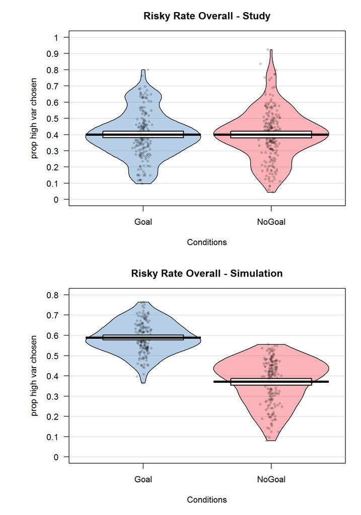

Figure 5: Proportion of high variance chosen separated for goal and no goal condition. Top: Study data. Bottom: Simulation Data.

```r
par(mfrow = c(2,1), mar=c(5,6.7,3,1.5))
yarrr::pirateplot(high.var.chosen.rate ~ goal.condition, data = df.participant,
           ylab = "prop high var chosen", xlab = "Conditions", main = "Risky Rate Overall - Study")
yarrr::pirateplot(high.var.chosen.rate ~ goal.condition, data = df.participant.s,
           ylab = "prop high var chosen", xlab = "Conditions", main = "Risky Rate Overall - Simulation")
```

### Probability of reaching 100 points in the goal and no goal condition

We assumed that in the goal condition the probability of reaching 100 points would be larger than in the no goal condition, because participants strategies should focus on reaching 100 points.

```r
## Check the probability of reaching 100 points.
# PREDICTION: The probability of reaching 100 points is higher in the goal vs. the no goal condition.
w.rg <- coin::wilcox_test(goalReachedRate ~ as.factor(goal.condition),
                          data = df.participant)
w.rg
```

```
##
##  Asymptotic Wilcoxon-Mann-Whitney Test
##
## data:  goalReachedRate by
##   as.factor(goal.condition) (Goal, NoGoal)
## Z = 1.8139, p-value = 0.06969
## alternative hypothesis: true mu is not equal to 0
```

```r
# effect size r
eff.r.rg <- as.numeric(w.rg@statistic@teststatistic / sqrt(nrow(df.participant)))
eff.r.rg
```

```
## [1] 0.0895821
```

Contrary to our prediction, a Wilcoxon-Mann-Whitney test showed no significant effect of the goal condition on the probability of reaching 100 points ($Z=1.81$, $p = .07$), $r = .09$. Figure 6 illustrates this with a comparison to our simulation data.

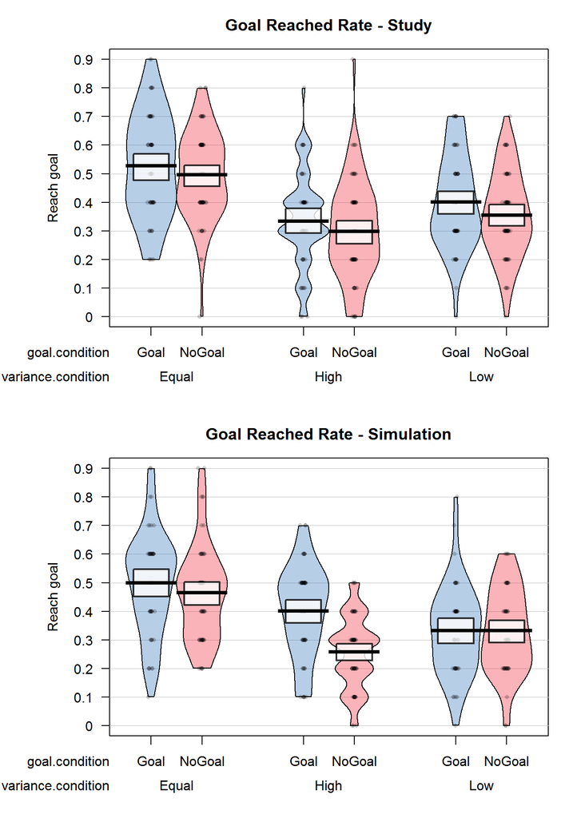

Figure 6: Probability of reaching 100 points, separated for goal and no goal condition. Top: Study Data. Bottom: Simulation Data.

```r
par(mfrow = c(2,1), mar=c(5,6.7,3,1.5))
yarrr::pirateplot(goalReachedRate ~ goal.condition + variance.condition, data = df.participant,
           ylab = "Reach goal", xlab = "Conditions", main = "Goal Reached Rate - Study")
yarrr::pirateplot(goalReachedRate ~ goal.condition + variance.condition, data = df.participant.s,
           ylab = "Reach goal", xlab = "Conditions", main = "Goal Reached Rate - Simulation")
```

### Number of points earned over variance conditions

We predicted tha tthe number of points earned was, on average, highest in the Equal environment. This is more a sort of sanity check, since in this environment both options have the same, high, EV. We tested the hypothesis with an ANOVA to also check if there were effects of the goal condition or an interaction.

```r
df.participant$goal.condition <- as.factor(df.participant$goal.condition)
df.participant$variance.condition <- as.factor(df.participant$variance.condition)

TAB <- afex::aov_ez(id = "id", dv = "points.cum", data = df.participant,
                    between = c("goal.condition", "variance.condition"), factorize = FALSE, return = "Anova")
```

```
## Contrasts set to contr.sum for the following variables: goal.condition, variance.condition
```

```r
# Partial eta squared and power
eff <- length(TAB[, 1]) - 2
Power <- vector(length = eff)
eta.sq <- vector(length = eff)
df2 <- TAB["Residuals", 2]

for (i in 1:eff){
  df1 <- TAB[i + 1, 2]
  eta.sq[i] <- TAB[i + 1, 1] / (TAB[i + 1, 1] + TAB["Residuals", 1])
  ncp <- TAB[i + 1, 3] * df1
  Fk <- qf(1-0.05, df1, df2)
  Power[i] <- 1 - pf(Fk, df1 = df1, df2 = df2, ncp = ncp)
}

# Table with eta squared and power
eta.sq.Power <- data.frame(eta.sq, Power)
rownames(eta.sq.Power) <- rownames(TAB)[-c(1, nrow(TAB))]

# Compute Least–Square-Means / Rand-Means
TAB2 <- lm(points.cum ~ variance.condition * goal.condition, data = df.participant)
ls.means <- lsmeans(TAB2, ~ variance.condition * goal.condition)

# print outputs
list(ANOVA=TAB, eta.sq.Power=eta.sq.Power, "Estimated Means"=ls.means)
```

```
## $ANOVA
## Anova Table (Type III tests)
##
## Response: dv
##                                      Sum Sq  Df    F value Pr(>F)
## (Intercept)                       322817506   1 22012.7899 <2e-16 ***
## goal.condition                        10181   1     0.6942 0.4052
## variance.condition                  2828839   2    96.4487 <2e-16 ***
## goal.condition:variance.condition     12102   2     0.4126 0.6622
## Residuals                           5924659 404
## ---
## Signif. codes:  0 '***' 0.001 '**' 0.01 '*' 0.05 '.' 0.1 ' ' 1
##
## $eta.sq.Power
##                                        eta.sq     Power
## goal.condition                    0.001715380 0.1321267
## variance.condition                0.323166670 1.0000000
## goal.condition:variance.condition 0.002038429 0.1167677
##
## $`Estimated Means`
##  variance.condition goal.condition    lsmean       SE  df lower.CL
##  Equal              Goal            991.2581 15.37960 404 961.0240
##  High               Goal            784.3279 15.50515 404 753.8470
##  Low                Goal            881.7273 14.90627 404 852.4237
##  Equal              NoGoal         1004.7733 13.98332 404 977.2842
##  High               NoGoal          805.5974 13.80053 404 778.4676
##  Low                NoGoal          876.9565 14.57862 404 848.2971
##   upper.CL
##  1021.4921
##   814.8087
##   911.0308
##  1032.2625
##   832.7272
##   905.6160
##
## Confidence level used: 0.95
```

```r
# check hypothesized contrast that Equal has the highest value
C <- list(c(2, -1, -1))
M <- lsmeans(TAB2, ~variance.condition)
```

```
## NOTE: Results may be misleading due to involvement in interactions
```

```r
contrast(M, C)
```

```
##  contrast     estimate       SE  df t.ratio p.value
##  c(2, -1, -1) 321.7269 25.46497 404  12.634  <.0001
##
## Results are averaged over the levels of: goal.condition
```

The ANOVA revealed a significant main effect of variance condition on the total number of points earned ($F(2, 404) = 96.45$, $p < .001$). A contrast analysis showed that, as predicted, in the Equal environment, total points were, on average, higher in the Equal than in the other environments ($t(404) = 12.63$, $p < .001$). Figure 7 shows this pattern for the study and simulation data. Note that the data didn’t match the predicted pattern in the high EV is high variance (High) condition.

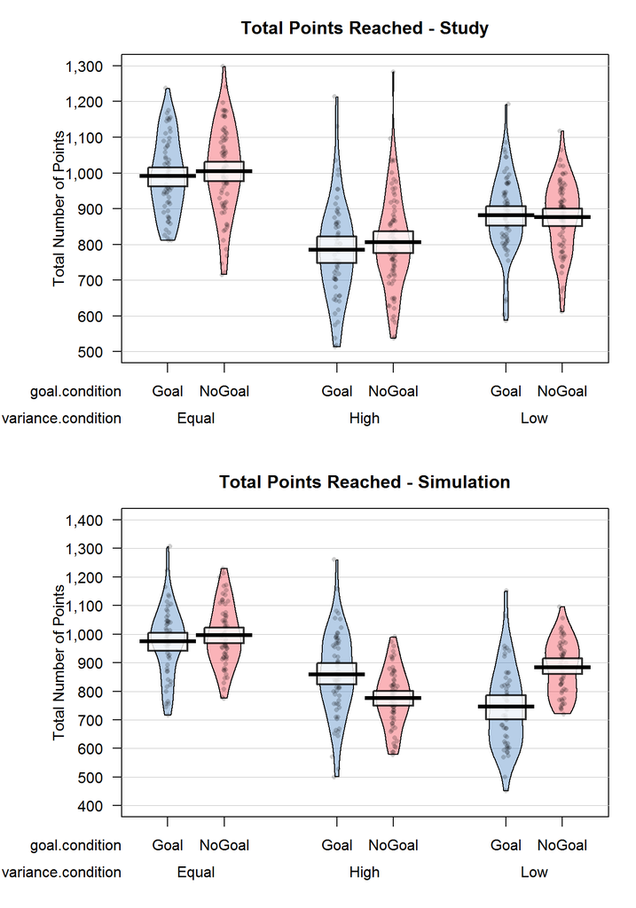

Figure 7: Total Points Reached, separated for goal and variance condition. Top: Study Data. Bottom: Simulation Data.

```r
par(mfrow = c(2,1), mar=c(5,6.7,3,1.5))
yarrr::pirateplot(points.cum ~ goal.condition + variance.condition, data = df.participant,
           ylab = "Total Number of Points", xlab = "Conditions", main = "Total Points Reached - Study")
yarrr::pirateplot(points.cum ~ goal.condition + variance.condition, data = df.participant.s,
           ylab = "Total Number of Points", xlab = "Conditions", main = "Total Points Reached - Simulation")
```

## Survey Data

Now let’s also look at the survey data. The mean age of participants was 36 years (range -36, 81). Of the 410included participants, 49% were female, 50% male and 1% didn’t specify their sex.

In the survey, participants were asked which strategy best described their behavior in the task: Either “I always tried to select the box that gives the most points on average.” (EV) or “I first looked at how many clicks I had left and how many points I had. Then, I selected one box or the other.” (RSF). Overall 63% chose the first strategy. Table 2 shows the proportion of strategy chosen separated for the goal and the variance condition. Note that we predicted there would be no difference in strategy reported for the goal condition. This prediction was erroneously made from the simulation data.

Proportion of participants in the variance and conditions choosing strategy 1 or 2.

|  |  | 1 | 2 |
| --- | --- | --- | --- |
| Variance Condition | Equal | 0.61 | 0.39 |
|  | High | 0.62 | 0.38 |
|  | Low | 0.67 | 0.33 |
| Goal Condition | Goal | 0.55 | 0.45 |
|  | NoGoal | 0.70 | 0.30 |

After having completed the bandit task, participants were asked which option they thought had, on average, the higher point value:

- High: “I think the option with the higher point variability also had higher values on average.”
- Low: “I think the option with the lower point variability had higher values on average.”
- Equal: “I think both options gave the same number of points on average.”

Table 3 shows participants answers to the question which option they thought to have the higher point value.

Percent of participants indicating, that a certain option had the higher EV, separated for variance and goal condition.

|  |  | High | Low | Equal |
| --- | --- | --- | --- | --- |
| variance condition | Equal | 0.55 | 0.13 | 0.31 |
|  | High | 0.55 | 0.12 | 0.33 |
|  | Low | 0.49 | 0.23 | 0.28 |
| goal condition | Goal | 0.53 | 0.14 | 0.33 |
|  | NoGoal | 0.53 | 0.18 | 0.29 |

Finally we predicted, that participants in the goal condition found it harder to earn points than those in the no goal condition.

```r
w.test <- coin::wilcox_test(game.difficulty ~ as.factor(goal.condition),
                            data = df.participant)
w.test
```

```
##
##  Asymptotic Wilcoxon-Mann-Whitney Test
##
## data:  game.difficulty by
##   as.factor(goal.condition) (Goal, NoGoal)
## Z = 7.9118, p-value = 2.442e-15
## alternative hypothesis: true mu is not equal to 0
```

```r
eff.r <- as.numeric(w.test@statistic@teststatistic / sqrt(nrow(df.participant)))
eff.r
```

```
## [1] 0.3907377
```

A Wilcoxon-Mann-Whitney test, confirmed this hypothesis ($Z = 7.91$, $p < .001$, $r = .39$).

# Unregistered Analyses

## Evidence Strength

Let’s see if there’s a relationship between how much the two strategies favor an option (evidence strength), and how likely it was to be chosen by participants. For this we first define a function to get the plots.

```r
### function definition ---------------
evidence_strength2 <- function(df, strategy, nround, nbatches, ...){
  if (strategy == "RSF") {
    fav.opt <- round(df$p.getthere.1.subj - df$p.getthere.2.subj, nround)
  } else if (strategy == "EV") {
    fav.opt <- round((df$subj.mean.1 / df$sd.sub1) - (df$subj.mean.2 / df$sd.sub2), nround)
  } else {
    stop("No valid strategy. Strategy must be either EV or RSF")
  }
  fav.opt[fav.opt == Inf | fav.opt == -Inf] <- NA

  # create batches
  batch.size <- (max(fav.opt, na.rm = TRUE) - min(fav.opt, na.rm = TRUE)) / nbatches

  batch.int <- cumsum(c(min(fav.opt, na.rm = TRUE), rep(batch.size, nbatches)))

  # compute the probability of choosing option 1, given a certain RSF.diff value
  p.choose.1 <- unlist(lapply(seq_len(nbatches),
                              function(x, df, fav.opt, batch.int){
                                mean(df$selection[fav.opt >= batch.int[x] &
                                                    fav.opt < batch.int[x+1]] == 1,
                                     na.rm = TRUE)
                              },
                              df = df, fav.opt = fav.opt, batch.int = batch.int))

  numobs <- unlist(lapply(seq_len(nbatches),
                          function(x, df, fav.opt, batch.int){
                            vec <- df$selection[fav.opt >= batch.int[x] &
                                                  fav.opt < batch.int[x+1]]
                            vec <- vec[!is.na(vec)]

                            lvec <- length(vec)

                            lvec

                          },
                          df = df, fav.opt = fav.opt, batch.int = batch.int))

  # scale the size ob points
  total.l <- length(df$selection[!is.na(df$selection)])

  numobs.s <- round(numobs / total.l, 2)


  # plot the results
  plot(batch.int[1:(length(batch.int)-1)] + (batch.size / 2), p.choose.1, type = "b",
       ylab = "p of Choosing Option 1", col = gray(0.3, .7), lwd = 2, cex = exp(numobs.s),
       cex.lab = 1.5, cex.axis = 1.5, ylim = c(0, 1), pch = 16, ...)

  text(x = batch.int[1:(length(batch.int)-1)] + (batch.size / 2),
       y = p.choose.1,
       labels = numobs.s, pos = 3)

  df.evidence <- data.frame("p.choose.1" = p.choose.1,
                            "batch.int" = batch.int[1:(length(batch.int)-1)] + (batch.size / 2),
                            "n.obs" = numobs,
                            "n.obs.s" = numobs.s)

  df.evidence
}
```

Figure 8 shows (only for the goal condition) the relation between RSF evidence strength for option A (i.e. the probability of option A getting you to the goal minus the probability of option B getting you to the goal) and the probability of choosing option A. We can see a (slight) positive relation between RSF evidence strength and the probability of choosing option A. One concern here is, that the evidence strenght is mostly relatively small, i.e. close to 0, therefore most of the data is pooled around 0.

```r
par(mfrow = c(4,1))
### Evidence in RSF strategy --------------
RSF.all2 <- evidence_strength2(subset(df.trial, goal.condition == "Goal"), "RSF", 2, 10,
                             xlab = "p getthere 1 - p getthere 2",
                             main = "Evidence Strength RSF, All Trials, Goal Condition")

# separated for variance conditions
RSF.equal2 <- evidence_strength2(subset(df.trial, goal.condition == "Goal" &
                                          variance.condition == "Equal"), "RSF", 2,
                              10, xlab = "p getthere 1 - p getthere 2",
                              main = "Evidence Strength RSF, Equal EVs, Goal Condition")

RSF.low2 <- evidence_strength2(subset(df.trial, goal.condition == "Goal" &
                                          variance.condition == "Low"), "RSF", 2,
                                 10, xlab = "p getthere 1 - p getthere 2",
                                 main = "Evidence Strength RSF, Low Variance, Goal Condition")

RSF.high2 <- evidence_strength2(subset(df.trial, goal.condition == "Goal" &
                                        variance.condition == "High"), "RSF", 2,
                               10, xlab = "p getthere 1 - p getthere 2",
                               main = "Evidence Strength RSF, High Variance, Goal Condition")
```

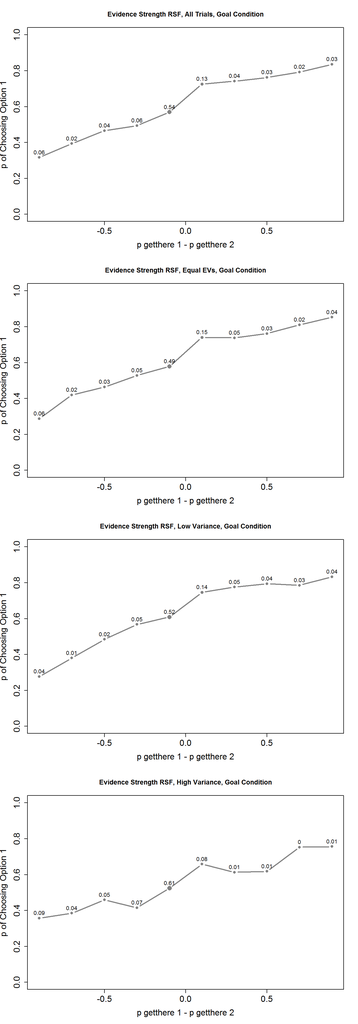

Figure 8: Probability of choosing option A as a function of RSF evidence strength for option A. Goal condition. Top to bottom: All trials, Equal, Low and High variance condition.

Figure 9 shows the relation between EV evidence strength (i.e. $\frac{\overline{A}}{s_{A}} - \frac{\overline{B}}{s_{B}}$) and the probability of choosing A for the goal condition. There is no clear positive relationship between the EV evidence strength and the probability of choosing A in the goal condition.

```r
par(mfrow = c(4,1))
### Evidence in EV strategy ---------------

# with the evidence2 function
EV.goal2 <- evidence_strength2(subset(df.trial, goal.condition == "Goal"), "EV", 0, 10,
                             xlab = "d prime 1 - d prime 2",
                             main = "Evidence Strength EV, All Trials, Goal Condition")


# let's check the different variance conditions separately

EV.goal.equal2 <- evidence_strength2(subset(df.trial, goal.condition == "Goal" &
                                              variance.condition == "Equal"), "EV", 0, 10,
                               xlab = "d prime 1 - d prime 2",
                               main = "Evidence Strength EV, Equal EVs, Goal Condition")

EV.goal.low2 <- evidence_strength2(subset(df.trial, goal.condition == "Goal" &
                                            variance.condition == "Low"), "EV", 0, 10,
                                     xlab = "d prime 1 - d prime 2",
                                     main = "Evidence Strength EV, Low variance, Goal Condition")

EV.goal.high2 <- evidence_strength2(subset(df.trial, goal.condition == "Goal" &
                                             variance.condition == "High"), "EV", 0, 10,
                                     xlab = "d prime 1 - d prime 2",
                                     main = "Evidence Strength EV, High Variance, Goal Condition")
```

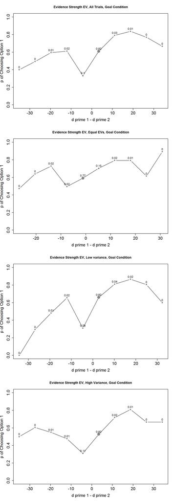

Figure 9: Probability of choosing option A as a function of EV evidence strength for option A. Goal condition. Top to bottom: All trials, Equal, Low and High variance condition.

Figure 10 shows the relationship between EV evidence strength and the probability of choosing option A for the no goal condition. There seems to be no clear relationship.

```r
par(mfrow = c(4,1))
EV.no.goal2 <- evidence_strength2(subset(df.trial, goal.condition == "NoGoal"), "EV", 0, 10,
                                xlab = "d prime 1 - d prime 2",
                                main = "Evidence Strength EV, All Trials, No Goal Condition")

EV.no.goal.equal.2 <- evidence_strength2(subset(df.trial, goal.condition == "NoGoal" &
                                                  variance.condition == "Equal"), "EV", 0, 10,
                                  xlab = "d prime 1 - d prime 2",
                                  main = "Evidence Strength EV, Equal EVs, No Goal Condition")

EV.no.goal.low.2 <- evidence_strength2(subset(df.trial, goal.condition == "NoGoal" &
                                                  variance.condition == "Low"), "EV", 0, 10,
                                         xlab = "d prime 1 - d prime 2",
                                         main = "Evidence Strength EV, Low Variance, No Goal Condition")

EV.no.goal.high.2 <- evidence_strength2(subset(df.trial, goal.condition == "NoGoal" &
                                                  variance.condition == "High"), "EV", 0, 10,
                                         xlab = "d prime 1 - d prime 2",
                                         main = "Evidence Strength EV, Equal EVs, No Goal Condition")
```

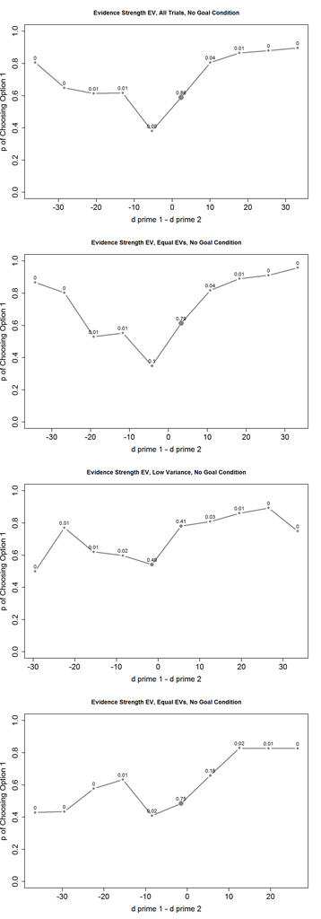

Figure 10: Probability of choosing option A as a function of EV evidence strength for option A. No Goal condition. Top to bottom: All trials, Equal, Low and High variance condition.

## Learning over games

To see whether participants learned over games, figure 11 shows the proportion of participants who reached the goal from game 1 to 10. It can be seen, that the curve is slighly increasing (from $p_{GoalReached} = .39$ to $p_{GoalReached} = .47$). The difference between the proportion of participants who reached the goal in game 1 and game 10 is not significant ($V = 1140$, $p = .08$).

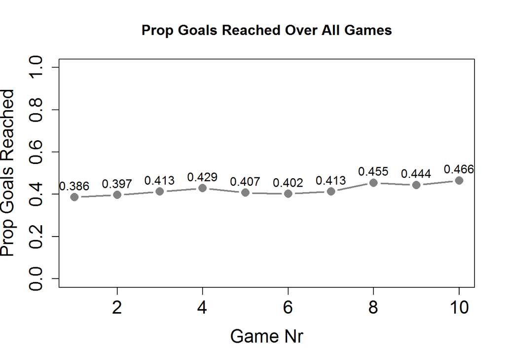

Figure 11: Proportion of participants reaching the goal over games.

```r
props <- unlist(lapply(2:11,
                       function(x, df){
                         mean(df$goalReachedRate[df$goal.condition == "Goal" & df$game == x])
                         },
                       df = df.game))

n.games <- 10

plot(1:n.games, props, xlab = "Game Nr", ylab = "Prop Goals Reached",
     main = "Prop Goals Reached Over All Games", type = "b", ylim = c(0, 1),
     pch = 16, col = gray(0.3, .7), lwd = 2, cex = 1.5, cex.lab = 1.5, cex.axis = 1.5)

text(1:n.games,
     y = props,
     labels = round(props, 3), pos = 3)
```

```r
wilcox.test(df.game$goalReachedRate[df.game$goal.condition == "Goal" & df.game$game == 2],
            df.game$goalReachedRate[df.game$goal.condition == "Goal" & df.game$game == 11],
            paired = TRUE)
```

```
##
##  Wilcoxon signed rank test with continuity correction
##
## data:  df.game$goalReachedRate[df.game$goal.condition == "Goal" & df.game$game ==  and df.game$goalReachedRate[df.game$goal.condition == "Goal" & df.game$game ==     2] and     11]
## V = 1140, p-value = 0.08381
## alternative hypothesis: true location shift is not equal to 0
```

To see whether participants in the no goal condition learned over games, Figure 12 shows the mean number of points earned from game 1 to 10. It can be seen, that the curve is slighly increasing (from $\overline{Points} = 89.45$ to $\overline{Points} = 94.69$). The difference between the number of points earned in the no goal condition in game 1 and game 10 is not significant ($V = 10335$, $p = .11$).

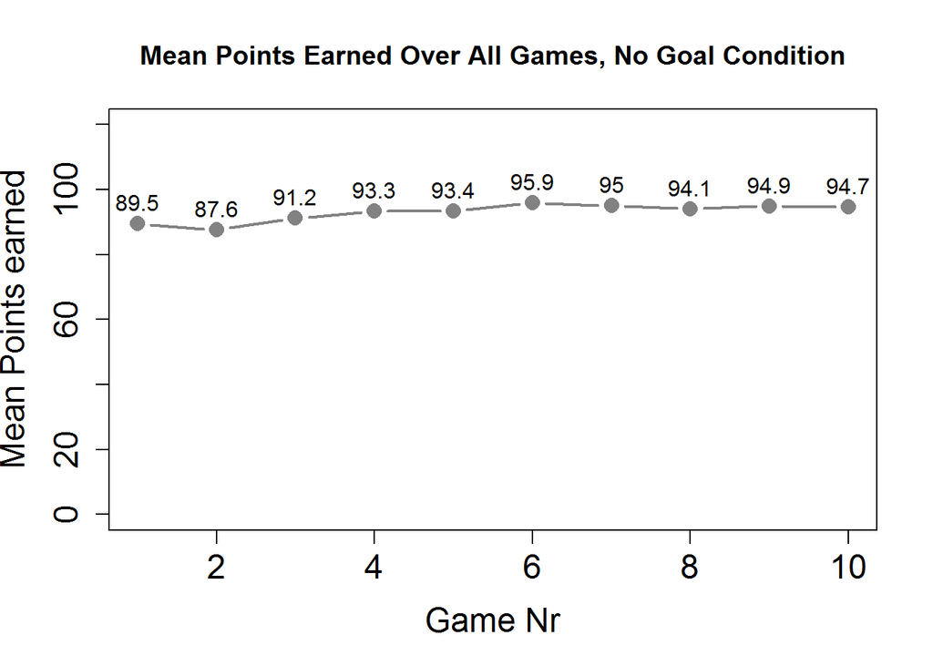

Figure 12: Average Number of points earned over games in the no goal condition.

```r
mean.points <- unlist(lapply(2:11,
                        function(x, df){
                          mean(df$points.cum[df$goal.condition == "NoGoal" & df$game == x])
                        },
                        df = df.game))

n.games <- 10

plot(1:n.games, mean.points, xlab = "Game Nr", ylab = "Mean Points earned",
     main = "Mean Points Earned Over All Games, No Goal Condition", type = "b", ylim = c(0, 120),
     pch = 16, col = gray(0.3, .7), lwd = 2, cex = 1.5, cex.lab = 1.5, cex.axis = 1.5)

text(1:n.games,
     y = mean.points,
     labels = round(mean.points, 1), pos = 3)
```

```r
wilcox.test(df.game$points.cum[df.game$goal.condition == "NoGoal" & df.game$game == 2],
            df.game$points.cum[df.game$goal.condition == "NoGoal" & df.game$game == 11],
            paired = TRUE)
```

```
##
##  Wilcoxon signed rank test with continuity correction
##
## data:  df.game$points.cum[df.game$goal.condition == "NoGoal" & df.game$game ==  and df.game$points.cum[df.game$goal.condition == "NoGoal" & df.game$game ==     2] and     11]
## V = 10335, p-value = 0.1073
## alternative hypothesis: true location shift is not equal to 0
```

Finally, Figure 13 shows, that participants in the goal condition do not act more in an RSF way in later than in early games.

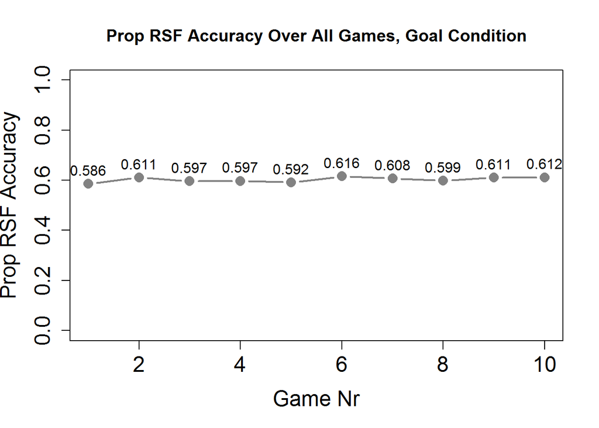

Figure 13: Proportion of RSF Accuracy over games in the goal condition.

```r
props.RSF.acc <- unlist(lapply(2:11,
                        function(x, df){
                          mean(df$pred.RSF.acc.rate[df$goal.condition == "Goal" & df$game == x])
                        },
                        df = df.game))

n.games <- 10

plot(1:n.games, props.RSF.acc, xlab = "Game Nr", ylab = "Prop RSF Accuracy",
     main = "Prop RSF Accuracy Over All Games, Goal Condition", type = "b", ylim = c(0, 1),
     pch = 16, col = gray(0.3, .7), lwd = 2, cex = 1.5, cex.lab = 1.5, cex.axis = 1.5)

text(1:n.games,
     y = props.RSF.acc,
     labels = round(props.RSF.acc, 3), pos = 3)
```

## Prediction accuracies for people who indicated that they followed RSF or EV.

```r
# get list of people in the goal condition who either selected the EV or RSF strategy
EV.ids.goal <- df.participant$id[df.participant$which.strategy == 1 &
                                   df.participant$goal.condition == "Goal"]
RSF.ids.goal <- df.participant$id[df.participant$which.strategy == 2 &
                                    df.participant$goal.condition == "Goal"]

# what are the mean accuracy rates for RSF and EV in the Goal condition
mean(df.participant$pred.RSF.acc.rate[df.participant$goal.condition == "Goal"])
```

```
## [1] 0.6027725
```

```r
mean(df.participant$pred.EV.acc.rate[df.participant$goal.condition == "Goal"])
```

```
## [1] 0.5937354
```

```r
# what are the mean accuracy rates for RSF and EV for the people that indicated
# that they would follow the respective strategy
mean(df.participant$pred.RSF.acc.rate[df.participant$which.strategy == 2 &
                                        df.participant$goal.condition == "Goal"])
```

```
## [1] 0.6044706
```

```r
mean(df.participant$pred.EV.acc.rate[df.participant$which.strategy == 1 &
                                       df.participant$goal.condition == "Goal"])
```

```
## [1] 0.6338846
```

We can see that the mean accuracies of the two models are only slightly higher when only participants are condsidered who indicated that they had followed the respective strategy. But when we look at the model predictions separated by whether participants had indicated that they had followed this respective model, we can see a difference.

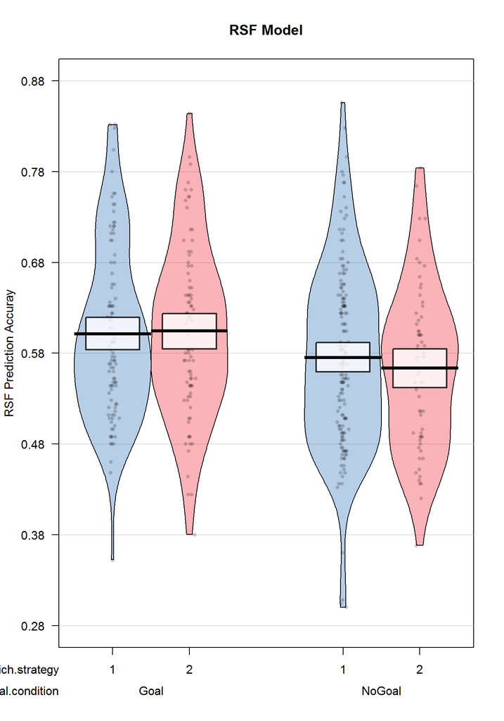

Figure 1: Model Accuracy separated for whether this model was supposedly followed and goal condition. Top: RSF Model. Bottom: EV Model.

```r
#plot the differences for the
pirateplot(pred.RSF.acc.rate ~ which.strategy + goal.condition, data = df.participant,
           main = "RSF Model", ylab = "RSF Prediction Accuray")
```

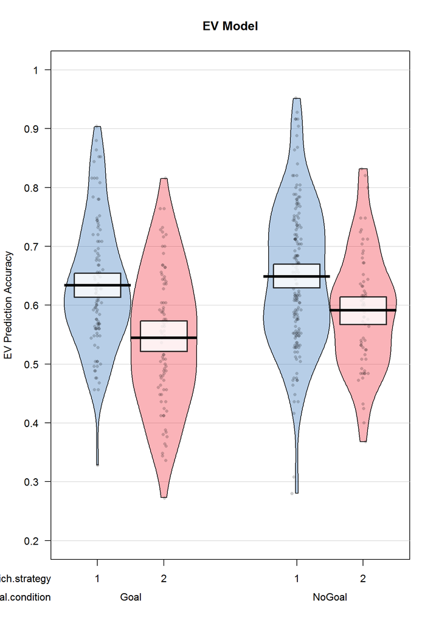

Figure 1: Model Accuracy separated for whether this model was supposedly followed and goal condition. Top: RSF Model. Bottom: EV Model.

```r
pirateplot(pred.EV.acc.rate ~ which.strategy + goal.condition, data = df.participant,
           main = "EV Model", ylab = "EV Prediction Accuracy")
```

Let’s test with a chi squared test if these differences are significant.

```r
m.RSF.1 <- with(subset(df.trial, game > 1 & goal.condition == "Goal" & id %in% RSF.ids.goal),
     mean(pred.RSF.acc[pred.EV != pred.RSF], na.rm = TRUE))
m.RSF.2 <- with(subset(df.trial, game > 1 & goal.condition == "Goal" & id %in% EV.ids.goal),
     mean(pred.RSF.acc[pred.EV != pred.RSF], na.rm = TRUE))

chisq.test(c(m.RSF.1, m.RSF.2))
```

```
##
##  Chi-squared test for given probabilities
##
## data:  c(m.RSF.1, m.RSF.2)
## X-squared = 0.013686, df = 1, p-value = 0.9069
```

```r
m.EV.1 <- with(subset(df.trial, game > 1 & goal.condition == "Goal" & id %in% RSF.ids.goal),
     mean(pred.EV.acc[pred.EV != pred.RSF], na.rm = TRUE))
m.EV.2 <- with(subset(df.trial, game > 1 & goal.condition == "Goal" & id %in% EV.ids.goal),
     mean(pred.EV.acc[pred.EV != pred.RSF], na.rm = TRUE))

chisq.test(c(m.EV.1, m.EV.2))
```

```
##
##  Chi-squared test for given probabilities
##
## data:  c(m.EV.1, m.EV.2)
## X-squared = 0.014685, df = 1, p-value = 0.9035
```